## Analytically solving a soil C cycling model using the Newton-Raphson method. Implemented using the `stode` function from the `rootSolve` package in R.

This Repository is an example of how to use the `stode` funtion in the `rootSolve` package in R, to solve for model outputs at steady-state. I was inspired to do this aftering seeing it used in [Wieder et al. 2015](http://www.geosci-model-dev-discuss.net/8/2011/2015/gmdd-8-2011-2015.pdf) to analytically solve the MIMICS model. I use the “carbon only” model from Schimel and Weintraub 2003 as the example model. The point of this function is to reduce how long model spin-up takes, so you start at steady state before you begin model experiments, or minimize the amount of time required to run the model to steady state. This can take a serious amount of time for models with hourly resolution.

## Model Code

This is how I code the model and normally run to steady state.

```r
t= 800 # number of days to run the model for
day = 0 #start at day 0

#initial pools
MBC = 28 #gleaned from figures in the manuscript
EnzC= 1.4 #multiplied initial MBC by Ke, 0.05.

#parameters
Kd = 1 #this is the K and SOC values collapsed as 1 term
Ke = 0.05 #this is the fraction of Uc that goes to enzymes
Kl = 0.05 #this is the enzyme turnover rate per day
Km = 0.022 #microbial maintenance rate for biomass
SUE = 0.5 #taken from manuscript- they say this is from literature
Kes = 0.3 # half saturation of enzymes on substrate constance
params<-c(Kd,Ke,Kl,Km,SUE,Kes,t)

#choose model outputs you want to track.need to specify again at end of model code (how do I change this so you only have to specify it here?)
outputs<-c('day','MBC','EnzC','R')
#create a matrix to save model outputs
out<- matrix(rep(0,t*length(outputs)),nrow=t,dimnames=list(NULL,outputs))


#run simulation t times
for(i in 1:t){
  #fluxes!
  Dc = Kd * (EnzC / (Kes + EnzC)) #decomposition
  Uc = Dc #upatke of C
  EPc = Ke * Uc #enzyme production
  ELc = Kl * EnzC # enzyme loss
  Re = EPc * ((1-SUE)/SUE) #enzyme production respiration
  Rm = Km * MBC #maintenance respiration
  Rg = (Uc - EPc - Re - Rm)*(1 - SUE) #growth respiration
  MBCg = (Uc - EPc - Re - Rm - Rg) #biomass growth
  R = Re + Rm + Rg
  #pools!
  MBC = MBC + MBCg
  EnzC = EnzC + EPc - ELc
  day = day + 1
  #update output matrix
  out[i,]<- c(day,MBC,EnzC,R)
  #end model loop
}
out<-data.frame(out)
```

Once the model has run 800 days the pools are near steady state.

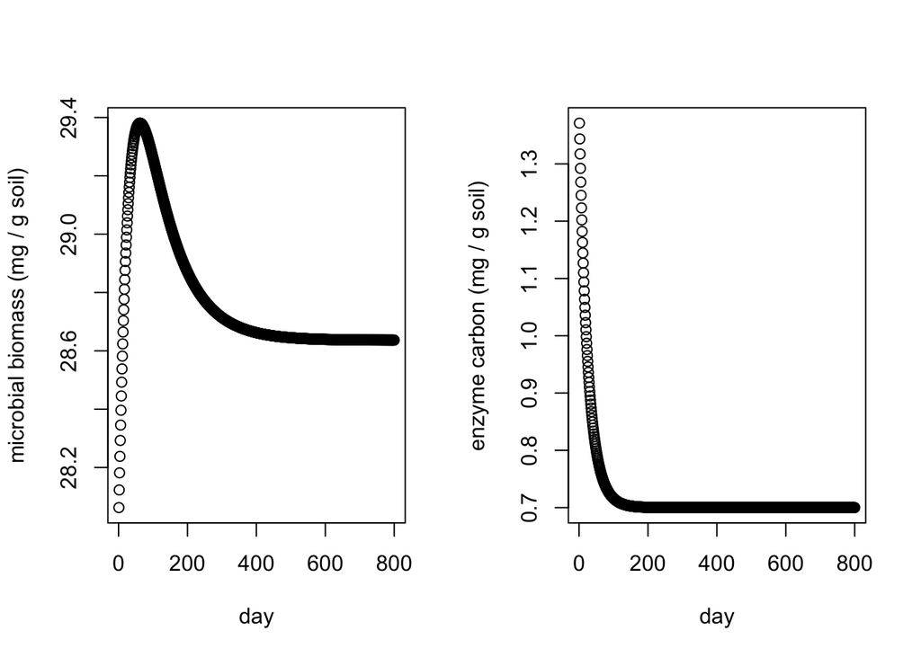

## Solving the model using `stode`

To adapt this model for use with the `stode` function we have to change a few things. First, We need to code the model as a function. Then we need to insert ordinary differential equations for each pool we want `stode` to solve for. Then we need to remove the lines that update the model pools, and how we save outputs.

```r
require(rootSolve)
model<-function(t,y,pars){
  with(as.list(c(y,pars)),{
    #fluxes!
    Dc = Kd * (EnzC / (Kes + EnzC)) #decomposition
    EPc = Ke * Dc #enzyme production
    ELc = Kl * EnzC # enzyme loss
    Re = EPc * ((1-SUE)/SUE) #enzyme production respiration
    Rm = Km * MBC #maintenance respiration
    Rg = (Uc - EPc - Re - Rm)*(1 - SUE) #growth respiration
    MBCg = (Uc - EPc - Re - Rm - Rg) #biomass growth
    R = Re + Rm + Rg
    #pools to solve for!
    dMBC = MBCg
    dEnzC = EPc - ELc
    list(c(dMBC,dEnzC))
  })
}
```

Note the strange bracketing to coax the output into a list. This is a formatting requirement of `stode`. If there is a better way to do this, I would love to hear it!

Now that the model is a function, with two ODEs at the end, we can solve it using Newton-Raphson! YEAH. First you need to specify all the model parameters and starting values for the pools.

```r
#specify parameter vector for stode
pars<-c(Kd=Kd,Ke=Ke,Kl=Kl,Km=Km,SUE=SUE,Kes=Kes)

#specify initial pool sizes, you are solving for steady state of these values.
y<-c(MBC=28,EnzC=1.4)

#run stode
ST<- stode(y=y,func=model,parms=pars,pos=T)
```

If this all works, go ahead and check the output.

```
## $y
##        MBC       EnzC
## 28.6363609  0.7000006
##
## attr(,"precis")
## [1] 1.482353e-02 2.032210e-03 4.143448e-05 2.093178e-08
## attr(,"steady")
## [1] TRUE
```

`stode` solves the model, and gives the precise values at steady state that the 800-day loop was converging towards.